# 2021 경제인문사회연구회 맞춤형

## 회귀진단 및 보정

회귀모형의 가정하에 모형적합을 한 후에는 모형과 가정에 대한 점검이 필요하며 이러한 과정에서 회귀진단 통계량을 이용한다.

회귀진단의 첫 번째 목적은 모형이 얼마나 데이터 상황을 잘 설명하느냐에 대한 점검이고

두 번째 목적은 추정에 있어 각 개체 또는 관측의 효과에 대해 점검하는 것이다.

이렇나 단계에서 잔차를 이용한 통계량을 사용할 수 있으며 잔차들이 모형의 가정을 따르지 않는다면

수립된 모형을 의심하고 새로인 적절한 모형을 다시 모색해야한다.

어떤 개체(또는 관측)을 제거 했을 때 분석 결과가 크게 달라지는 관측을 영향점(influential point)라한다

또한 나머지 경우들과는 달리 동떨어져 잔차가 큰 경향이 있는 관측을 이상점(outlier)라고 한다.

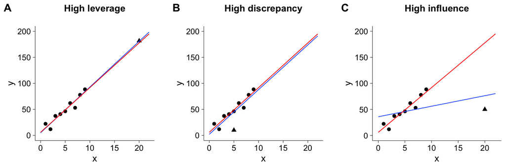

패널 A에서 삼각형이있는 데이터 포인트는 레버리지가 높으며 x 값은 나머지 값보다 훨씬 높습니다. (레버리지 값)

패널 B에서는 불일치가 높기 때문에 가장 잘 맞는 라인에서 멀리 떨어져 있습니다. 그러나 빨간색 선이 파란색 선과 크게 다르지 않기 때문에 이러한 점 중 어느 것도 모델 매개 변수에 많은 영향을 미치지 않습니다.

패널 C에서 우리는 레버리지가 높고 불일치가 높고 그 결과 영향이 큰 점을 입니다. 파란색 선은 빨간색 선과 매우 다릅니다. (이상점)

### 레버리지 (지렛대점)

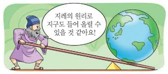

지렛대의 길이가 길면 적은 힘으로도 무거운 물건을 움직이게 할 수 있다.

회귀모형에서도 이와 마찬가지이다.

패널 A의 있냐? 없냐?에 따라 추정된 회귀모형의 회귀계수에 큰 영향을 미치지 않지만, (빨간색 : 없었을때, 파란색 : 있었을때)

이를 회귀분석에서는 influence 분석이라 칭하며, 모자행렬 H를 통해 얻어진다.

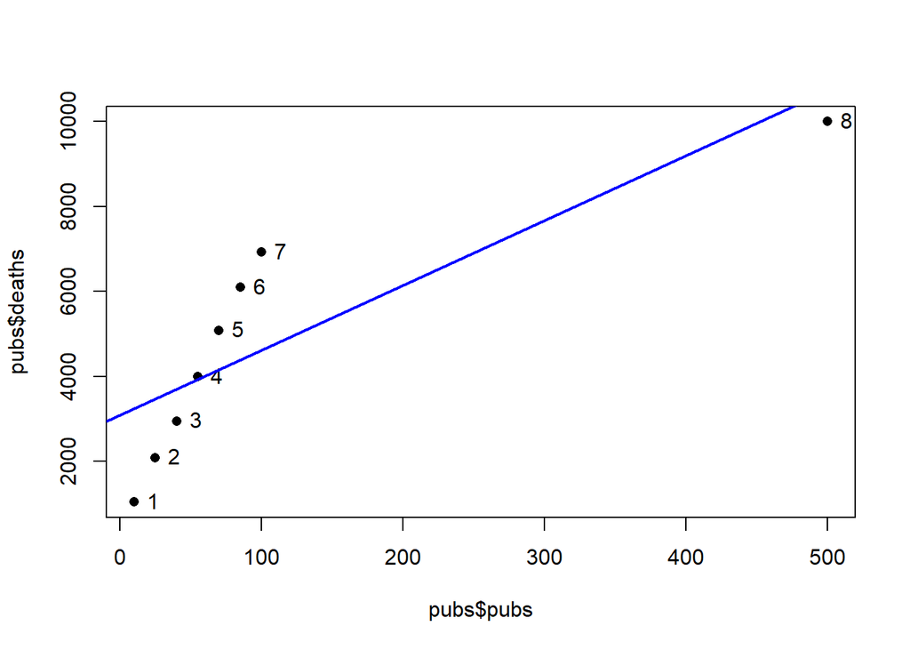

```r
pubs <- data.frame(pubs=c(10,25,40,55,70,85,100,500),
                   deaths=c(1043.822,2086.934,2951.086,3992.459,5088.003,6095.645,6923.497,10000),
                   name=1:8)

plot(pubs$pubs, pubs$deaths, pch=16)
text(pubs$pubs, pubs$deaths, labels=pubs$name, pos=4)
abline(lm(deaths~pubs, data=pubs), col="blue", lwd=2)
```

A. Field, J. Miles and Z. Field. Discovering Statistics Using R. London and Thousand Oaks, CA: Sage, 2012.

의 예제자료를 이용해서 레버리지, 불일치 그리고 이상치를 알아보자.

참고로 x축은 런던의 지역별 맥주집(pub)의 수, y축은 해당자치구의 사망자 수이다.

지렛대는 R의 hatvlues()함수와 influence()함수를 이용하면 쉽게 얻을 수 있다.

```r
fit.pub <- lm(deaths~pubs, data=pubs)
influence(fit.pub)
```

```
## $hat
##         1         2         3         4         5         6         7         8
## 0.1813863 0.1658284 0.1527766 0.1422307 0.1341907 0.1286567 0.1256287 0.9693020
##
## $coefficients
##   (Intercept)         pubs
## 1  -500.64698   1.50031016
## 2  -293.58347   0.78756483
## 3  -147.73112   0.34480258
## 4    12.90085  -0.02509125
## 5   162.17071  -0.24454463
## 6   277.00211  -0.28076852
## 7   347.99908  -0.15652823
## 8  2696.51037 -50.89913526
##
## $sigma
##          1          2          3          4          5          6          7
## 1488.30201 1712.76322 1805.11785 1840.53257 1785.03687 1647.43945 1471.33636
##          8
##   75.42461
##
## $wt.res
##           1           2           3           4           5           6
## -2191.75744 -1377.77856  -742.75967    69.48021   935.89110  1714.39999
##           7           8
##  2313.11887  -720.59450
```

```r
hatvalues(fit.pub)
```

```
##         1         2         3         4         5         6         7         8
## 0.1813863 0.1658284 0.1527766 0.1422307 0.1341907 0.1286567 0.1256287 0.9693020
```

일반적으로 지렛대점으로 볼수 있는 임계값은 hatvalue의 평균의 2배 값이다.

pubs 자료의 모자행렬 요소의 평균값으 0.25이고 이를 2배 곱하면 0.5이다.

따라서 8번째 있는 0.969302로 표현된 값이 지렛대 점으로 볼 수 있다.

지렛대점은 독립변수들의 상자그림을 통해서도 짐작할 수 있다.

```r
mean(hatvalues(fit.pub))*2 #지렛대점 기준
```

```
## [1] 0.5
```

```r
hatvalues(fit.pub)
```

```
##         1         2         3         4         5         6         7         8
## 0.1813863 0.1658284 0.1527766 0.1422307 0.1341907 0.1286567 0.1256287 0.9693020
```

```r
hatvalues(fit.pub)[hatvalues(fit.pub)>mean(hatvalues(fit.pub))*2]
```

```
##        8
## 0.969302
```

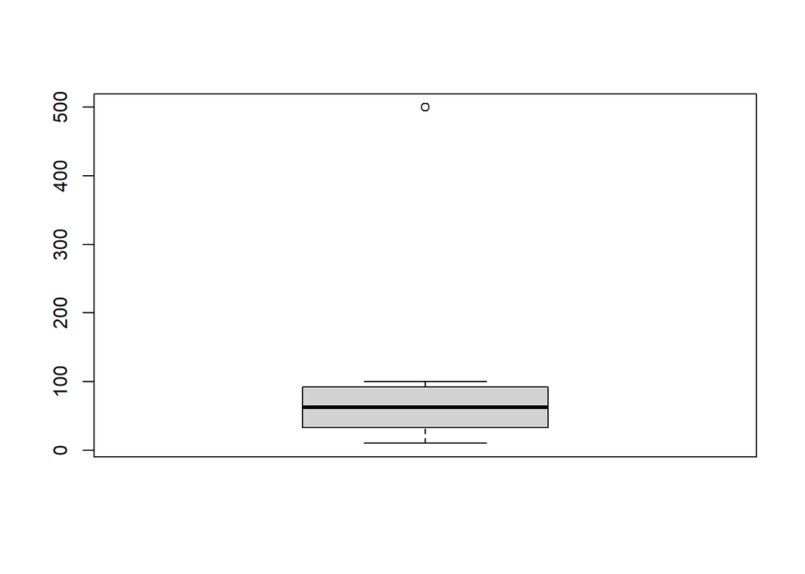

```r
boxplot(pubs$pubs)
```

모자행렬을 행렬을 통해 구한다면,

$$H = X(X'X)^{-1}X'$$
X Design matrix를 만든 후 위의 행렬을 계산하여 대각행렬을 구해주면 된다.

```r
X <- cbind(rep(1,nrow(pubs)),pubs$pubs)
X <- as.matrix(X)

hat.mtx <- X%*% solve(t(X) %*% X) %*% t(X)
diag(hat.mtx)
```

```
## [1] 0.1813863 0.1658284 0.1527766 0.1422307 0.1341907 0.1286567 0.1256287
## [8] 0.9693020
```

```r
hatvalues(fit.pub)
```

```
##         1         2         3         4         5         6         7         8
## 0.1813863 0.1658284 0.1527766 0.1422307 0.1341907 0.1286567 0.1256287 0.9693020
```

### 불일치

이제 선형모형으로 추정된 식과 그 추정된 식을 통해 생성된 잔차를 살펴보자.

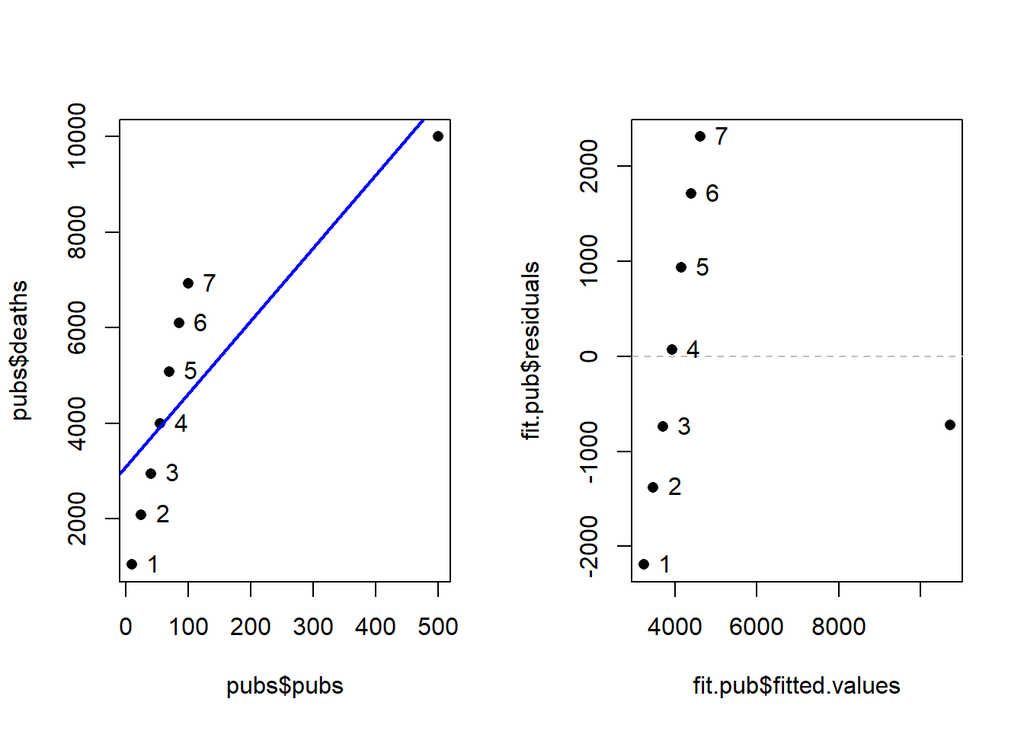

```r
par(mfrow=c(1,2))

plot(pubs$pubs, pubs$deaths, pch=16)
text(pubs$pubs, pubs$deaths, labels=pubs$name, pos=4)
abline(lm(deaths~pubs, data=pubs), col="blue", lwd=2)

plot(fit.pub$fitted.values, fit.pub$residuals, pch=16)
abline(h=0, lty=2, col="grey")
text(fit.pub$fitted.values, fit.pub$residuals, labels=pubs$name, pos=4)
```

왼쪽 그림을 관측값과 추정된 선형식 그리고 오른쪽 그림은 예측값과 잔차도표이다.

잔차도표를 보면 1번과 7번에 비해 8번의 잔차가 작다. 하지만 영향력 분석 결과 8번째 값은 영향점이였다.

스튜던트화 잔차(standentized residual)은 영향력을 고려한 잔차값으로 다음 식으로 계산된다.

$$r_i = {{e_i} \over {\sigma_i \sqrt{1-h_i}}}$$

```r
par(mfrow=c(1,1))
influence(fit.pub)
```

```
## $hat
##         1         2         3         4         5         6         7         8
## 0.1813863 0.1658284 0.1527766 0.1422307 0.1341907 0.1286567 0.1256287 0.9693020
##
## $coefficients
##   (Intercept)         pubs
## 1  -500.64698   1.50031016
## 2  -293.58347   0.78756483
## 3  -147.73112   0.34480258
## 4    12.90085  -0.02509125
## 5   162.17071  -0.24454463
## 6   277.00211  -0.28076852
## 7   347.99908  -0.15652823
## 8  2696.51037 -50.89913526
##
## $sigma
##          1          2          3          4          5          6          7
## 1488.30201 1712.76322 1805.11785 1840.53257 1785.03687 1647.43945 1471.33636
##          8
##   75.42461
##
## $wt.res
##           1           2           3           4           5           6
## -2191.75744 -1377.77856  -742.75967    69.48021   935.89110  1714.39999
##           7           8
##  2313.11887  -720.59450
```

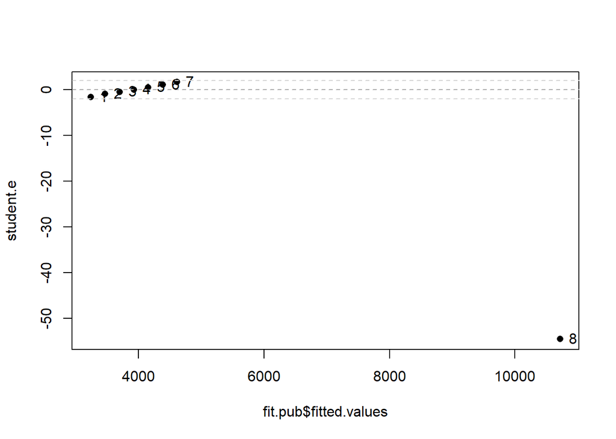

```r
student.e <- fit.pub$residuals/sqrt(1-influence(fit.pub)$hat)/influence(fit.pub)$sigma

plot(fit.pub$fitted.values, student.e, pch=16)
abline(h=0, lty=2, col="darkgrey")
text(fit.pub$fitted.values, student.e, labels=pubs$name, pos=4)
abline(h=c(2,-2), lty=2, col="lightgrey")
```

영향력을 고려하여 잔차를 보정한 스튜전트화 잔차는 t분포를 따르고 대략적으로 -2와 2를 기준으로 살펴보면,

8번째 값이 -54.528로 95% 신뢰구간을 벗어나 불일치한 자료로 판단된다.

위의 식처럼 복잡하게 계산하지 않더라도 r에서는 rstudent()함수를 통해 스튜던트화 잔차를 구할 수 있다.

```r
student.e
```

```
##            1            2            3            4            5            6
##  -1.62765333  -0.88075356  -0.44703731   0.04075983   0.56346508   1.11482846
##            7            8
##   1.68127219 -54.52839824
```

```r
rstudent(fit.pub)
```

```
##            1            2            3            4            5            6
##  -1.62765333  -0.88075356  -0.44703731   0.04075983   0.56346508   1.11482846
##            7            8
##   1.68127219 -54.52839824
```

- 하지만, 임계값을 넘어가는 값이라고 해서 그 점이 나쁜 값은 아니므로 해석에 주의할 필요성이 있다.
- outlierTest() 함수를 이용하면 임계값을 넘어가는 이상점을 확인할 수 있다.

```r
library(car)
outlierTest(fit.pub)
```

```
##   rstudent unadjusted p-value Bonferroni p
## 8 -54.5284         3.9231e-08   3.1385e-07
```

### 영향점

어떤 특정 관측값이 있을 때와 그것을 제외했을 때 적합된 회귀식에 큰 차이가 생기면 이를 영향점이라 한다.

즉 $n$개의 관측값 중 $i$번째를 제외한 $n-1$개의 관측을 이용하여 추정한 회귀식(1)과

$n$개를 모두 사용하여 추정한 회귀식(2) 간 결과가 달라진다면 이 값은 영향점이 된다.

영향점은 cooks.distance()함수를 이용한 `cook의 거리`와 dffits()함수를 이용한 `dffits 통계량`으로 판단한다.

$$DFFITS_i = E_i \sqrt{\frac{h_i}{1-h_i}}$$

여기서 $E_i$의 스튜던트화잔차이고 $h_i$는 모자행렬 값이다.

만약 $|dffits| > 2 \sqrt{\frac{k+1}{n-k-1}}$이면 영향점으로 판단한다.

```r
rstudent(fit.pub)*sqrt(hatvalues(fit.pub)/(1-hatvalues(fit.pub)))
```

```
##             1             2             3             4             5
##   -0.76616909   -0.39269578   -0.18983364    0.01659754    0.22182837
##             6             7             8
##    0.42838041    0.63728610 -306.40591808
```

```r
dffits(fit.pub)
```

```
##             1             2             3             4             5
##   -0.76616909   -0.39269578   -0.18983364    0.01659754    0.22182837
##             6             7             8
##    0.42838041    0.63728610 -306.40591808
```

```r
k=length(fit.pub$coefficients)
2*sqrt((1+k)/(nrow(pubs)-k-1))
```

```
## [1] 1.549193
```

```r
dffits(fit.pub)[abs(dffits(fit.pub))>2*sqrt((1+k)/(nrow(pubs)-k-1))]
```

```
##         8
## -306.4059
```

### 한꺼번에..

ls.diag()함수를 이용하면 위의 지렛대, 불일치, 영향력 분석을 모두 수행할 수 있다.

```r
ls.diag(fit.pub)
```

```
## $std.dev
## [1] 1680.448
##
## $hat
## [1] 0.1813863 0.1658284 0.1527766 0.1422307 0.1341907 0.1286567 0.1256287
## [8] 0.9693020
##
## $std.res
## [1] -1.44154418 -0.89769067 -0.48020238  0.04464274  0.59853447  1.09293034
## [7]  1.47205817 -2.44743280
##
## $stud.res
## [1]  -1.62765333  -0.88075356  -0.44703731   0.04075983   0.56346508
## [6]   1.11482846   1.68127219 -54.52839824
##
## $cooks
## [1] 2.302244e-01 8.009900e-02 2.079110e-02 1.652321e-04 2.776186e-02
## [6] 8.818568e-02 1.556728e-01 9.456717e+01
##
## $dfits
## [1]   -0.76616909   -0.39269578   -0.18983364    0.01659754    0.22182837
## [6]    0.42838041    0.63728610 -306.40591808
##
## $correlation
##             (Intercept)       pubs
## (Intercept)   1.0000000 -0.5939999
## pubs         -0.5939999  1.0000000
##
## $std.err
##                   [,1]
## (Intercept) 738.537926
## pubs          3.965572
##
## $cov.scaled
##             (Intercept)        pubs
## (Intercept)  545438.268 -1739.66255
## pubs          -1739.663    15.72576
##
## $cov.unscaled
##               (Intercept)          pubs
## (Intercept)  0.1931503750 -6.160486e-04
## pubs        -0.0006160486  5.568801e-06
```

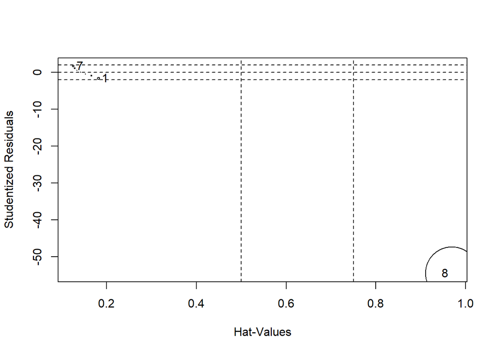

```
##      StudRes       Hat      CookD
## 1  -1.627653 0.1813863  0.2302244
## 7   1.681272 0.1256287  0.1556728
## 8 -54.528398 0.9693020 94.5671657
```

```r
influencePlot(fit.pub)
```

### 회귀모형의 교정

회귀모형 진단에서 문제가 발견된 경우, `관측치 제거`로 교정한다.

영향 관측치는 결과에 불균형한 영향을 미칠 수 있으므로 제거할 수 있다. 즉, 이상치나 영향관측치를 제거하여 다시 회귀모형에 적합시킨다. 그 후 다시 이상치나 영향관측치가 있는지 확인한 후 만족할 만한 모형적합을 얻을때까지 반복한다.

다시 한 번 관측치를 제거할 경우 매우 주의하여야 한다는 점을 강조하고 싶다. 어떤 경우는 관측치가 이상치인 이유가 기록할 때 잘못 기록했다든지 프로토콜을 따르지 않았다든지 피실험자가 지시 사항을 이해하지 못했다든지 하는 이유일 수 있다. 이러한 경우는 이상치를 제거하는 것이 정당하다.

하지만 다른 경우는 이러한 이상관측치가 여러분이 모은 데이터 중 가장 흥미로운 데이터일 수 있다. 이상관측치가 왜 다른 나머지 관측치와 다른지 밝혀내는 것이 지금 현재의 연구 주제뿐 아니라 여러분이 생각해 낼 수 있는 다른 연구주 제의 통찰에 크게 기여할 수 있다.

어쩌면 우리가 가지고 있는 지식의 큰 진보는 우리의 예상과 맞지 않는 무엇인가를 우연히 발견하는 데서부터 시작하는 경우가 있다.

## 혼자서 해보기

```r
fit <- lm(mpg~disp+hp+wt+drat, data=mtcars)
summary(fit)
```

```
##
## Call:
## lm(formula = mpg ~ disp + hp + wt + drat, data = mtcars)
##
## Residuals:
##     Min      1Q  Median      3Q     Max
## -3.5077 -1.9052 -0.5057  0.9821  5.6883
##
## Coefficients:
##              Estimate Std. Error t value Pr(>|t|)
## (Intercept) 29.148738   6.293588   4.631  8.2e-05 ***
## disp         0.003815   0.010805   0.353  0.72675
## hp          -0.034784   0.011597  -2.999  0.00576 **
## wt          -3.479668   1.078371  -3.227  0.00327 **
## drat         1.768049   1.319779   1.340  0.19153
## ---
## Signif. codes:  0 '***' 0.001 '**' 0.01 '*' 0.05 '.' 0.1 ' ' 1
##
## Residual standard error: 2.602 on 27 degrees of freedom
## Multiple R-squared:  0.8376, Adjusted R-squared:  0.8136
## F-statistic: 34.82 on 4 and 27 DF,  p-value: 2.704e-10
```

### 1. 모자행렬과 지렛대 점은?

### 2. 이상치가 있는지 찾아보세요?

### 3 영향점이 있는가? 있다면 어떤 자료인가?

### 4. 회귀모형 교정을 통해 회귀모형을 세우면?